# IODS course project

Phuong Nguyen:

# About the project

The course is a very good way to learn about open science, open data, and open research tools. There will be chances to utilize advanced statistical methods for visualizing and analyzing data sets.

Free and open software tools are used throughout the course to apply principle of *reproducible research* for its practical purposes.

Here is the [link](https://github.com/phuongfi91/IODS-project) to my GitHub project.

# 1. Regression and model validation

This week we learn how to predict values of one random variable based on information from other variables, using **regression analysis**. We explore **simple linear regression**, then **multiple linear regression**. Finally, we learn how to validate the assumptions we make about the model(s) using diagnostics.

### Data from international survey of Approaches to Learning

The dataset is a result from the international survey of Approaches to Learning in 2013-2015. More detailed information about the original survey dataset can be found here http://www.helsinki.fi/~kvehkala/JYTmooc/JYTOPKYS3-meta.txt.

This dataset describes the result of the survey through students basic personal properties in relation to the study approaches they took.

Personal properties include:

- Gender
- Age
- Attitude (toward statistics)
- Points (earned from exam)

Study approaches:

- Deep: seeking meaning, relating ideas, use of evidence
- Surface: lack of purpose, unrelated memorising, syllabus-boundness
- Strategic: organized studying, time management

The dataset includes 166 records with the 7 variables mentioned above:

```r
dim(learning2014)
```

```
## [1] 166   7
```

A brief look into the dataset tell us the following:

- *Gender* is represented by **gender**, with Female being 1, Male being 2
- *Age* (**age**) is recorded using regular integer number
- *Attitude* (**age**) is the sum of 10 questions related to attitude towards statistics, normalized to the scale from 1-5
- *Points* is the **points** earned from exam
- *Deep approach* (**deep**), *Surface approach* (**surf**), *Strategic approach* (**stra**) are the mentioned study approaches used by students in an Introductory Statistics Course. Value is the average of responses ranging from 1-5

```r
str(learning2014)
```

```
## 'data.frame':    166 obs. of  7 variables:
##  $ gender  : Factor w/ 2 levels "F","M": 1 2 1 2 2 1 2 1 2 1 ...
##  $ age     : int  53 55 49 53 49 38 50 37 37 42 ...
##  $ attitude: num  3.7 3.1 2.5 3.5 3.7 3.8 3.5 2.9 3.8 2.1 ...
##  $ points  : int  25 12 24 10 22 21 21 31 24 26 ...
##  $ deep    : num  3.58 2.92 3.5 3.5 3.67 ...
##  $ surf    : num  2.58 3.17 2.25 2.25 2.83 ...
##  $ stra    : num  3.38 2.75 3.62 3.12 3.62 ...
```

### Graphical overview and summaries of the data

The following summaries describe the value range of each variable, as discussed in the previous section. There are twice as many female students compared to male students in the survey. The majority of students are in their 20s.

```r
summary(learning2014)
```

```
##  gender       age           attitude         points           deep
##  F:110   Min.   :17.00   Min.   :1.400   Min.   : 7.00   Min.   :1.583
##  M: 56   1st Qu.:21.00   1st Qu.:2.600   1st Qu.:19.00   1st Qu.:3.333
##          Median :22.00   Median :3.200   Median :23.00   Median :3.667
##          Mean   :25.51   Mean   :3.143   Mean   :22.72   Mean   :3.680
##          3rd Qu.:27.00   3rd Qu.:3.700   3rd Qu.:27.75   3rd Qu.:4.083
##          Max.   :55.00   Max.   :5.000   Max.   :33.00   Max.   :4.917
##       surf            stra
##  Min.   :1.583   Min.   :1.250
##  1st Qu.:2.417   1st Qu.:2.625
##  Median :2.833   Median :3.188
##  Mean   :2.787   Mean   :3.121
##  3rd Qu.:3.167   3rd Qu.:3.625
##  Max.   :4.333   Max.   :5.000
```

To understand the dataset better, we need to look at the overall picture and the correlation between variables in the graph below.

By interpreting from the density plots on the diagonal line, it can be seen that male students have generally more positive **attitude** toward statistics. Female students have a bit more tendency toward **surface** and **strategic** learning methods. However, overall there is very little difference when it comes to the final exam **points** between the two genders.

There is, however, a strong correlation between **attitude** and the exam **points**. Exam result seems to rise along with **attitude**. There is also a slight correlation between **surface** and **strategy** study methods against exam **points**. Exam score reduces as student lean toward **surface** method, while it rises along with **strategical** approach.

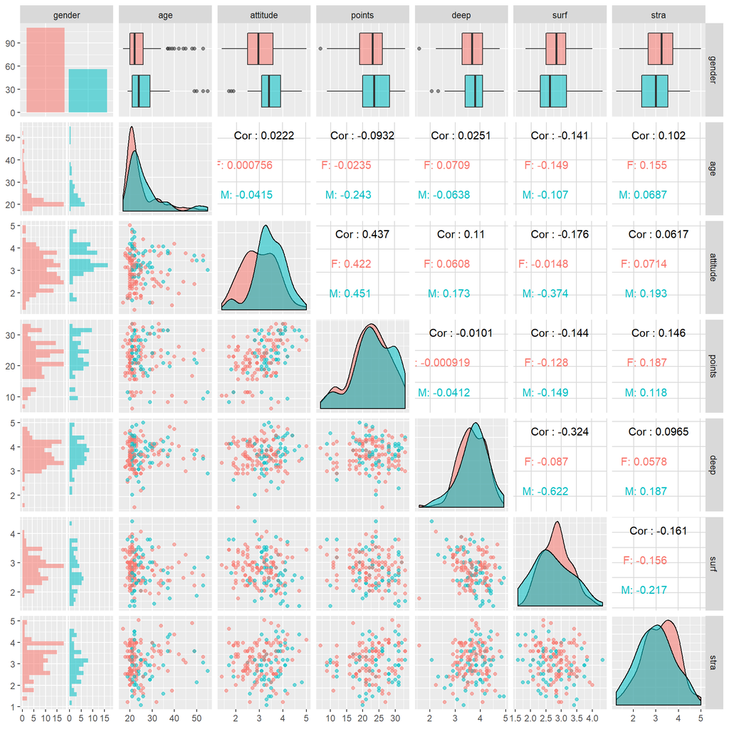

### Regression model

To analyze further the relationship between target variable and explanatory variables, we examine a fitted model and interpret the results. We will start by choosing three explanatory variables. As discussed the the previous section, **attitude**, **surface** and **strategical** learning methods have a good correlation with the target variable points. We build a model based on those.

**Attitude** has quite a small standard error compared to its estimate value. Unlike attitude, both **surf** and **stra** have rather large errors. **T-value**, which is a standard statistical test (used to reject null hypothesis), the larger the value, the more well established the relationship between variables. Similarly with p-value (**Pr(>|t|)**), it’s used to test variables relationship, however, the smaller the value, the better, as it suggests that it’s unlikely the relationship is due to chance. In this case, **attitude** is the only variable that seems to have said qualities (high **t-value** and low **p-value**), thus, it’s the only statistically significant explanatory variable.

```
##
## Call:
## lm(formula = points ~ attitude + surf + stra, data = learning2014)
##
## Residuals:
##      Min       1Q   Median       3Q      Max
## -17.1550  -3.4346   0.5156   3.6401  10.8952
##
## Coefficients:
##             Estimate Std. Error t value Pr(>|t|)
## (Intercept)  11.0171     3.6837   2.991  0.00322 **
## attitude      3.3952     0.5741   5.913 1.93e-08 ***
## surf         -0.5861     0.8014  -0.731  0.46563
## stra          0.8531     0.5416   1.575  0.11716
## ---
## Signif. codes:  0 '***' 0.001 '**' 0.01 '*' 0.05 '.' 0.1 ' ' 1
##
## Residual standard error: 5.296 on 162 degrees of freedom
## Multiple R-squared:  0.2074, Adjusted R-squared:  0.1927
## F-statistic: 14.13 on 3 and 162 DF,  p-value: 3.156e-08
```

By removing **surf** and **stra** variables, we now have a new model. This time, both the **intercept** and **attitude** have higher **t-value** and lower **p-value**.

```
##
## Call:
## lm(formula = points ~ attitude, data = learning2014)
##
## Residuals:
##      Min       1Q   Median       3Q      Max
## -16.9763  -3.2119   0.4339   4.1534  10.6645
##
## Coefficients:
##             Estimate Std. Error t value Pr(>|t|)
## (Intercept)  11.6372     1.8303   6.358 1.95e-09 ***
## attitude      3.5255     0.5674   6.214 4.12e-09 ***
## ---
## Signif. codes:  0 '***' 0.001 '**' 0.01 '*' 0.05 '.' 0.1 ' ' 1
##
## Residual standard error: 5.32 on 164 degrees of freedom
## Multiple R-squared:  0.1906, Adjusted R-squared:  0.1856
## F-statistic: 38.61 on 1 and 164 DF,  p-value: 4.119e-09
```

### Establishing the relationship

As assumed in the beginning through observation of the plots, **attitude** seems to have a relationship with **points**. The higher the **attitude**, the higher the **points**. The estimate value of 3.5255 represents the slope of change. The higher (steeper) the slope, the faster the change and the more effect on **points**.

The R-squared statistic determine how well the model is fitting the actual data. The value is range between 0 and 1. The value of 0.1906 mean roughly 19% of the variance in the response data can be explained by the model (using **attitude**). Multiple regression causes R-squared value to increase as more variables are added into the model, hence the existence of **Multiple R-squared** and **Adjusted R-squared** values. The **Adjusted R-squared** value takes into account the presence of multiple variables.

### Graphical model validation

The variance is assumed to be constant, in which it means the size of error shoud not be dependent on the explanatory variable. If we look at the first plot down below (**Residuals vs Fitted**), it can be seen that the spread is relatively constant as the value increases, despite a small few outliers.

The second assumption is the normality of the distribution. The **Normal Q-Q** plot below can be used to validate our model. As seen from the plot, the distribution seems to follow the line quite closely, despite a slight deviation at the beginning and the end, which might make the model slightly questionable.

The last test check whether or not some observations have a high impact on the regression line. As seen from the **Residuals vs Leverage** plot down below, there are a lot of points scattering in the plot, pulling the line and shape it into what we see. While the pulling effect seems to be the reasonable cause for the shape of the line, it remains rather questionable whether the model can actually perform well to predict incoming values.

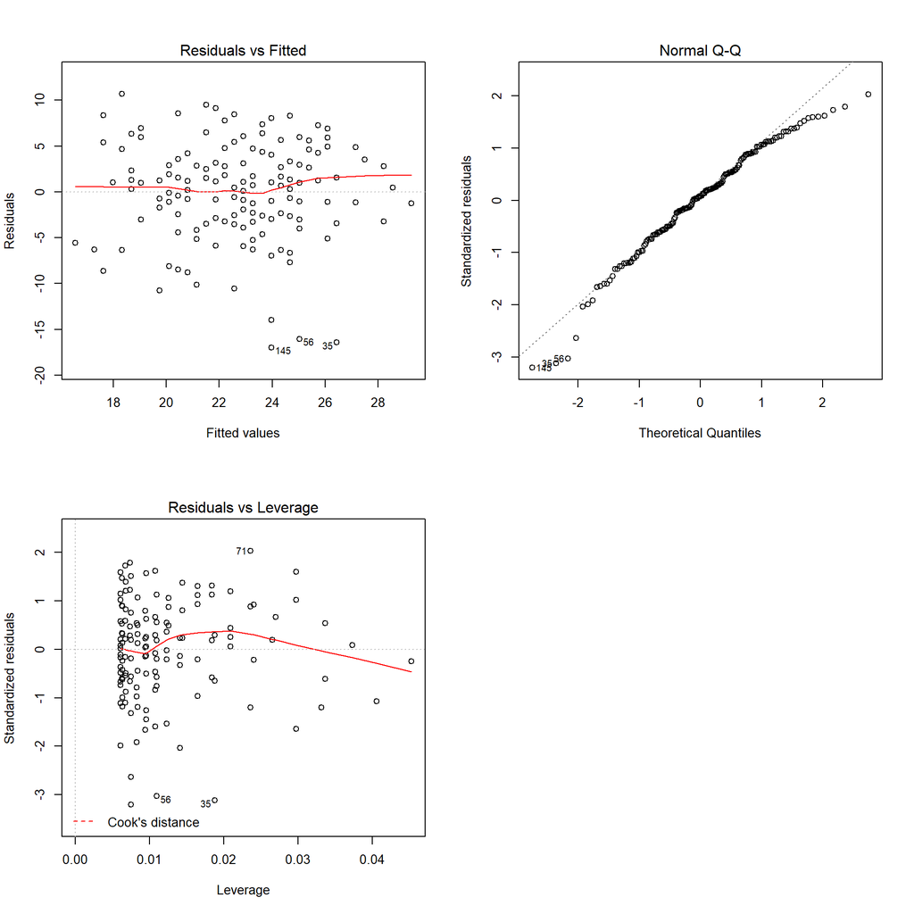

# 2. Logistic regression

One way to move on from linear regression is to consider settings where the dependent (target) variable is **discrete**. This opens a wide range of possibilities for modelling phenomena beyond the assumptions of continuity or normality.

**Logistic regression** is a powerful method that is well suited for predicting and classifying data by working with **probabilities**. It belongs to a large family of statistical models called **Generalized Linear Models** (GLM). An important special case that involves a **binary** target (taking only the values 0 or 1) is the most typical and popular form of logistic regression.

We will learn the concept of **odds ratio** (OR), which helps to understand and interpret the estimated coefficients of a logistic regression model. We also take a brief look at **cross-validation**, an important principle and technique for assessing the performance of a statistical model with another data set, for example by splitting the data into a **training set** and a **testing set**.

### Data set information

The dataset is a result of high school student performance measured from two Portuguese schools, in relation to their alcohol consumption. More detailed information about the original dataset can be found here https://archive.ics.uci.edu/ml/datasets/Student+Performance.

This dataset uses “school”, “sex”, “age”, “address”, “famsize”, “Pstatus”, “Medu”, “Fedu”, “Mjob”, “Fjob”, “reason”, “nursery”,“internet” as (student) identifiers. The rest are personal attributes describing their life, performance and alcohol consumptions.

The dataset includes 382 records with the 35 variables comprised of the mentioned above. **high_use** is determined based on quantified value of **alc_use**. **alc_use** is calculated based on both weekday (**Dalc**) and weekend (**Walc**) alcohol consumption:

```r
str(alc)
```

```
## 'data.frame':    382 obs. of  35 variables:
##  $ school    : Factor w/ 2 levels "GP","MS": 1 1 1 1 1 1 1 1 1 1 ...
##  $ sex       : Factor w/ 2 levels "F","M": 1 1 1 1 1 2 2 1 2 2 ...
##  $ age       : int  18 17 15 15 16 16 16 17 15 15 ...
##  $ address   : Factor w/ 2 levels "R","U": 2 2 2 2 2 2 2 2 2 2 ...
##  $ famsize   : Factor w/ 2 levels "GT3","LE3": 1 1 2 1 1 2 2 1 2 1 ...
##  $ Pstatus   : Factor w/ 2 levels "A","T": 1 2 2 2 2 2 2 1 1 2 ...
##  $ Medu      : int  4 1 1 4 3 4 2 4 3 3 ...
##  $ Fedu      : int  4 1 1 2 3 3 2 4 2 4 ...
##  $ Mjob      : Factor w/ 5 levels "at_home","health",..: 1 1 1 2 3 4 3 3 4 3 ...
##  $ Fjob      : Factor w/ 5 levels "at_home","health",..: 5 3 3 4 3 3 3 5 3 3 ...
##  $ reason    : Factor w/ 4 levels "course","home",..: 1 1 3 2 2 4 2 2 2 2 ...
##  $ nursery   : Factor w/ 2 levels "no","yes": 2 1 2 2 2 2 2 2 2 2 ...
##  $ internet  : Factor w/ 2 levels "no","yes": 1 2 2 2 1 2 2 1 2 2 ...
##  $ guardian  : Factor w/ 3 levels "father","mother",..: 2 1 2 2 1 2 2 2 2 2 ...
```

[output cut: 21 more lines]

### Hypotheses

Amongst the variables, student final grade (**G3**), **absences**, weekly study time (**studytime**) as well as whether or not student go out with friends (**goout**) are some of the major factors that might influence their alcohol consumption. The consumption is generally known for affecting human cognitive performance and sleep/wake cycles, therefore student **G3**, **absences** and **studytime** are possibly associated. Socializing habit such as going out with friends is culturally associated with alcohol usage, thus **goout** is another factor to be examined.

### Numerical and graphical overview

Here is a brief summary of the dataset:

```
##  school   sex          age        address famsize   Pstatus
##  GP:342   F:198   Min.   :15.00   R: 81   GT3:278   A: 38
##  MS: 40   M:184   1st Qu.:16.00   U:301   LE3:104   T:344
##                   Median :17.00
##                   Mean   :16.59
##                   3rd Qu.:17.00
##                   Max.   :22.00
##       Medu            Fedu             Mjob           Fjob
##  Min.   :0.000   Min.   :0.000   at_home : 53   at_home : 16
##  1st Qu.:2.000   1st Qu.:2.000   health  : 33   health  : 17
##  Median :3.000   Median :3.000   other   :138   other   :211
##  Mean   :2.806   Mean   :2.565   services: 96   services:107
##  3rd Qu.:4.000   3rd Qu.:4.000   teacher : 62   teacher : 31
##  Max.   :4.000   Max.   :4.000
##         reason    nursery   internet    guardian     traveltime
##  course    :140   no : 72   no : 58   father: 91   Min.   :1.000
##  home      :110   yes:310   yes:324   mother:275   1st Qu.:1.000
##  other     : 34                       other : 16   Median :1.000
##  reputation: 98                                    Mean   :1.448
##                                                    3rd Qu.:2.000
##                                                    Max.   :4.000
##    studytime        failures      schoolsup famsup     paid     activities
##  Min.   :1.000   Min.   :0.0000   no :331   no :144   no :205   no :181
##  1st Qu.:1.000   1st Qu.:0.0000   yes: 51   yes:238   yes:177   yes:201
##  Median :2.000   Median :0.0000
##  Mean   :2.037   Mean   :0.2016
##  3rd Qu.:2.000   3rd Qu.:0.0000
##  Max.   :4.000   Max.   :3.0000
##  higher    romantic      famrel         freetime        goout
##  no : 18   no :261   Min.   :1.000   Min.   :1.00   Min.   :1.000
##  yes:364   yes:121   1st Qu.:4.000   1st Qu.:3.00   1st Qu.:2.000
##                      Median :4.000   Median :3.00   Median :3.000
##                      Mean   :3.937   Mean   :3.22   Mean   :3.113
##                      3rd Qu.:5.000   3rd Qu.:4.00   3rd Qu.:4.000
##                      Max.   :5.000   Max.   :5.00   Max.   :5.000
##       Dalc            Walc           health         absences
##  Min.   :1.000   Min.   :1.000   Min.   :1.000   Min.   : 0.0
##  1st Qu.:1.000   1st Qu.:1.000   1st Qu.:3.000   1st Qu.: 1.0
##  Median :1.000   Median :2.000   Median :4.000   Median : 3.0
##  Mean   :1.482   Mean   :2.296   Mean   :3.573   Mean   : 4.5
##  3rd Qu.:2.000   3rd Qu.:3.000   3rd Qu.:5.000   3rd Qu.: 6.0
##  Max.   :5.000   Max.   :5.000   Max.   :5.000   Max.   :45.0
##        G1              G2              G3           alc_use
##  Min.   : 2.00   Min.   : 4.00   Min.   : 0.00   Min.   :1.000
##  1st Qu.:10.00   1st Qu.:10.00   1st Qu.:10.00   1st Qu.:1.000
##  Median :12.00   Median :12.00   Median :12.00   Median :1.500
##  Mean   :11.49   Mean   :11.47   Mean   :11.46   Mean   :1.889
##  3rd Qu.:14.00   3rd Qu.:14.00   3rd Qu.:14.00   3rd Qu.:2.500
##  Max.   :18.00   Max.   :18.00   Max.   :18.00   Max.   :5.000
##   high_use
##  Mode :logical
##  FALSE:268
##  TRUE :114
##
##
##
```

Student final grade (**G3**) can range from 0 to 20, with the maximum value in the dataset being 18. **Absences** purely represent the number of absences at school (from 0 to 93). **goout** is a numerical value, which range from 1 - very low to 5 - very high. **studytime** is also numerical, with `1 - <2 hours`, `2 - 2 to 5 hours`, `3 - 5 to 10 hours`, `or 4 - >10 hours`.

The following tables give initial hint that support the aforementioned hypotheses, where high alcohol consumption is linked to worse school performance and a more social life style.

```
## # A tibble: 2 x 3
##   high_use count mean_grade
##   <lgl>    <int>      <dbl>
## 1 FALSE      268       11.7
## 2 TRUE       114       10.8
```

```
## # A tibble: 2 x 3
##   high_use count mean_absences
##   <lgl>    <int>         <dbl>
## 1 FALSE      268          3.71
## 2 TRUE       114          6.37
```

```
## # A tibble: 2 x 3
##   high_use count mean_study_time
##   <lgl>    <int>           <dbl>
## 1 FALSE      268            2.15
## 2 TRUE       114            1.77
```

```
## # A tibble: 2 x 3
##   high_use count mean_go_out
##   <lgl>    <int>       <dbl>
## 1 FALSE      268        2.85
## 2 TRUE       114        3.72
```

The following box plots depict the data in a more detailed manner. Even with outliers considered, the data still pretty much in line with the initial hypotheses.

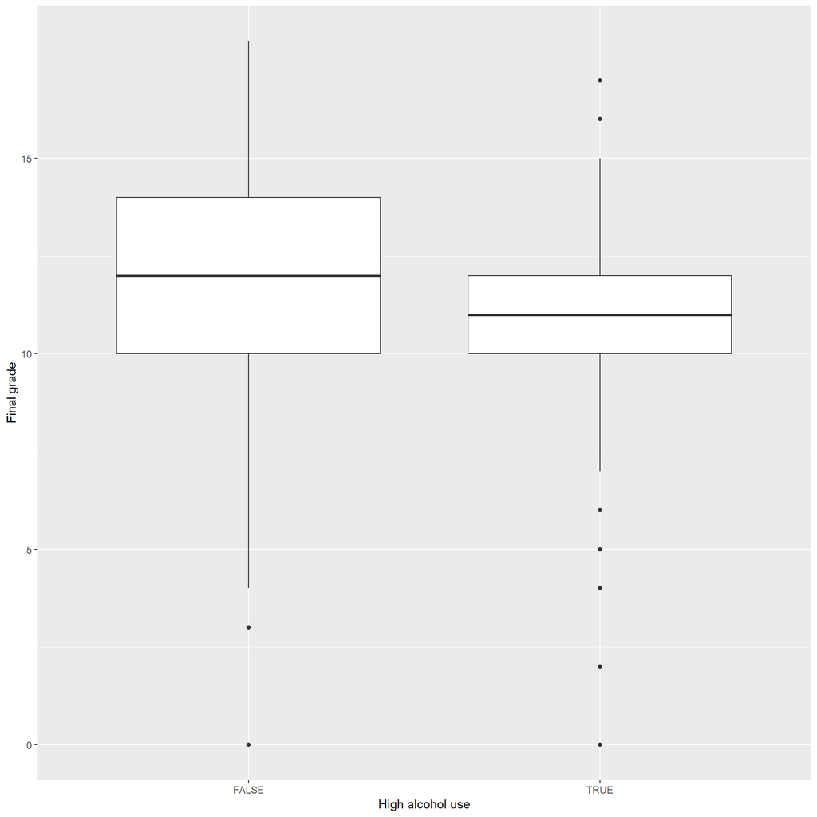

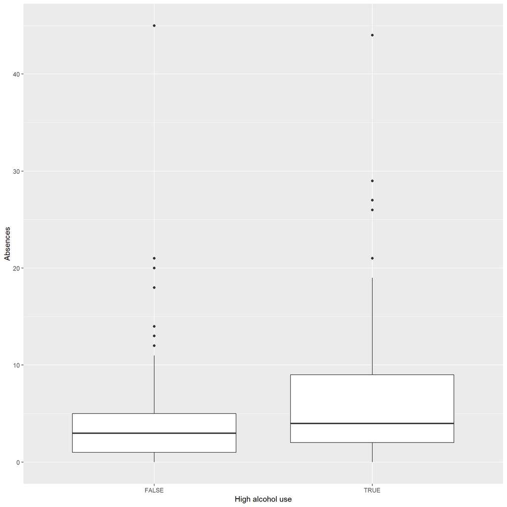

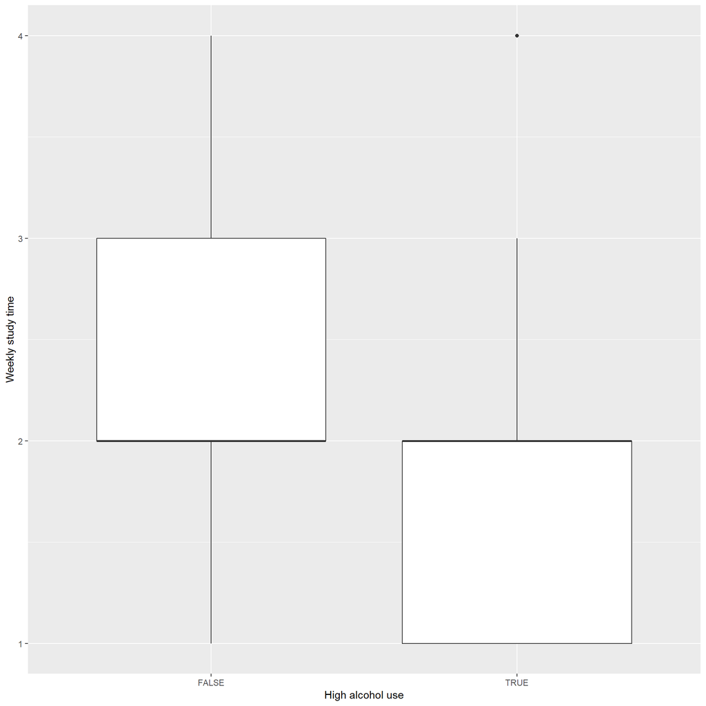

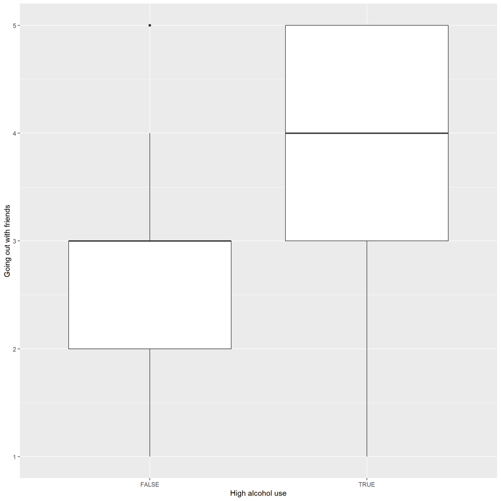

### Logistic regression model and establishing relationships

To make another step towards validating the hypotheses, a logistic regression model is created with **high_use** being the target variable and **G3**, **absences**, **studytime** and **goout** as explanatory variable.

```
##
## Call:
## glm(formula = high_use ~ G3 + absences + studytime + goout, family = "binomial",
##     data = alc)
##
## Deviance Residuals:
##     Min       1Q   Median       3Q      Max
## -1.8717  -0.7686  -0.5171   0.8345   2.4941
##
## Coefficients:
##             Estimate Std. Error z value Pr(>|z|)
## (Intercept) -2.15991    0.69106  -3.125  0.00178 **
## G3          -0.02831    0.03925  -0.721  0.47074
## absences     0.06912    0.02205   3.135  0.00172 **
## studytime   -0.54223    0.16834  -3.221  0.00128 **
## goout        0.71610    0.11855   6.040 1.54e-09 ***
## ---
## Signif. codes:  0 '***' 0.001 '**' 0.01 '*' 0.05 '.' 0.1 ' ' 1
##
## (Dispersion parameter for binomial family taken to be 1)
##
##     Null deviance: 465.68  on 381  degrees of freedom
## Residual deviance: 389.62  on 377  degrees of freedom
## AIC: 399.62
##
## Number of Fisher Scoring iterations: 4
```

With the presented summary of the model above, the absolute **z value** being pretty small and **p value** being rather large for **G3** (final grade). It can be concluded that **G3** is not statistically significant enough to be used as a part of the model. Another simpler model is used instead.

```
##
## Call:
## glm(formula = high_use ~ absences + studytime + goout, family = "binomial",
##     data = alc)
##
## Deviance Residuals:
##     Min       1Q   Median       3Q      Max
## -1.8457  -0.7733  -0.5178   0.8432   2.5036
##
## Coefficients:
##             Estimate Std. Error z value Pr(>|z|)
## (Intercept) -2.48582    0.52982  -4.692 2.71e-06 ***
## absences     0.07011    0.02204   3.181 0.001470 **
## studytime   -0.56048    0.16672  -3.362 0.000774 ***
## goout        0.72735    0.11786   6.171 6.78e-10 ***
## ---
## Signif. codes:  0 '***' 0.001 '**' 0.01 '*' 0.05 '.' 0.1 ' ' 1
##
## (Dispersion parameter for binomial family taken to be 1)
##
##     Null deviance: 465.68  on 381  degrees of freedom
## Residual deviance: 390.14  on 378  degrees of freedom
## AIC: 398.14
##
## Number of Fisher Scoring iterations: 4
```

Odd ratios and confidence intervals is calculated in the table below. Odd ratios of all predictors are well within the range of corresponding confidence intervals. All interval are in general quite narrow, meaning that the model is performing rather well. This confirms previously stated hypotheses ragarding **absences**, **studytime** and **goout** variables.

```
##                     OR      2.5 %    97.5 %
## (Intercept) 0.08325721 0.02864231 0.2297441
## absences    1.07262851 1.02840235 1.1225709
## studytime   0.57093348 0.40733791 0.7846264
## goout       2.06958310 1.65203749 2.6250666
```

### Predictive power

The model managed to predict correctly the majority of cases when the high use is false. It, however, doesn’t perform as well when trying to predict cases where high use is actually true.

```
##         prediction
## high_use FALSE TRUE
##    FALSE   246   22
##    TRUE     66   48
```

The following graph visualizes the actual values and the predictions.

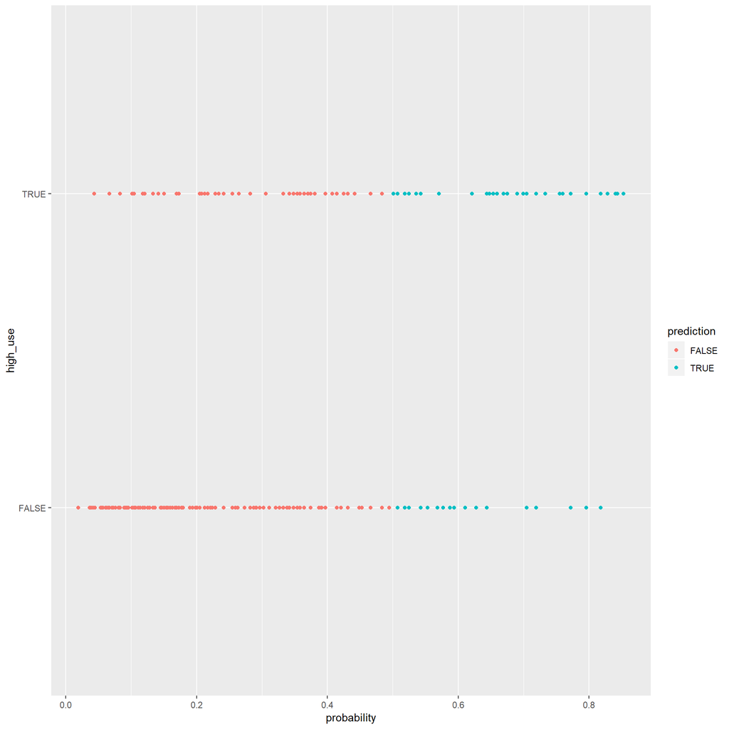

The proportion of inaccurately classified individuals is calculated using the loss function defined below:

```r
# loss function definition
loss_func <- function(class, prob) {
  n_wrong <- abs(class - prob) > 0.5
  mean(n_wrong)
}

# compute the proportion of wrong predictions in the (training) data
loss_func(class = alc$high_use, prob = alc$probability)
```

```
## [1] 0.2303665
```

# 3. Clustering and classification

The topics of this chapter - clustering and classification - are handy and **visual tools** of **exploring statistical data**. Clustering means that some points (or observations) of the data are in some sense **closer** to each other than some other points. In other words, the data points do not comprise a homogeneous sample, but instead, it is somehow clustered.

In general, the clustering methods try to **find these clusters** (or groups) from the data. One of the most typical clustering methods is called **k-means clustering**. Also **hierarchical clustering** methods quite popular, giving tree-like **dendrograms** as their main output.

As such, clusters are easy to find, but what might be the “right” number of clusters? It is not always clear. And how to give these clusters names and interpretations?

Based on a successful clustering, we may try to **classify** new observations to these clusters and hence validate the results of clustering. Another way is to use various forms of **discriminant analysis**, which operates with the (now) known clusters, asking: “what makes the difference(s) between these groups (clusters)?”

In the connection of these methods, we also discuss the topic of **distance** (or **dissimilarity** or **similarity**) measures. There are lots of other measures than just the ordinary Euclidean distance, although it is one of the most important ones. Several discrete and even binary measures exist and are widely used for different purposes in various disciplines.

### Data set information

The Boston dataset is one of the included dataset in the MASS library. The dataset describes housing values in suburbs of Boston. The following variables exist in the dataset, with **medv** being the target variable.

- **crim**: per capita crime rate by town.
- **zn**: proportion of residential land zoned for lots over 25,000 sq.ft.
- **indus**: proportion of non-retail business acres per town.
- **chas**: Charles River dummy variable (= 1 if tract bounds river; 0 otherwise).
- **nox**: nitrogen oxides concentration (parts per 10 million).
- **rm**: average number of rooms per dwelling.
- **age**: proportion of owner-occupied units built prior to 1940.
- **dis**: weighted mean of distances to five Boston employment centres.
- **rad**: index of accessibility to radial highways.
- **tax**: full-value property-tax rate per $10,000.
- **ptratio**: pupil-teacher ratio by town.
- **black**: 1000(Bk - 0.63)^2 where Bk is the proportion of blacks by town.
- **lstat**: lower status of the population (percent).
- **medv**: median value of owner-occupied homes in $1000s.

```
## 'data.frame':    506 obs. of  14 variables:
##  $ crim   : num  0.00632 0.02731 0.02729 0.03237 0.06905 ...
##  $ zn     : num  18 0 0 0 0 0 12.5 12.5 12.5 12.5 ...
##  $ indus  : num  2.31 7.07 7.07 2.18 2.18 2.18 7.87 7.87 7.87 7.87 ...
##  $ chas   : int  0 0 0 0 0 0 0 0 0 0 ...
##  $ nox    : num  0.538 0.469 0.469 0.458 0.458 0.458 0.524 0.524 0.524 0.524 ...
##  $ rm     : num  6.58 6.42 7.18 7 7.15 ...
##  $ age    : num  65.2 78.9 61.1 45.8 54.2 58.7 66.6 96.1 100 85.9 ...
##  $ dis    : num  4.09 4.97 4.97 6.06 6.06 ...
##  $ rad    : int  1 2 2 3 3 3 5 5 5 5 ...
##  $ tax    : num  296 242 242 222 222 222 311 311 311 311 ...
##  $ ptratio: num  15.3 17.8 17.8 18.7 18.7 18.7 15.2 15.2 15.2 15.2 ...
##  $ black  : num  397 397 393 395 397 ...
##  $ lstat  : num  4.98 9.14 4.03 2.94 5.33 ...
##  $ medv   : num  24 21.6 34.7 33.4 36.2 28.7 22.9 27.1 16.5 18.9 ...
```

### Graphical and Numerical Overview

Most of the variables have their own measuring units as mentioned in the previous section. **chas** is simply represented using a binary value (0 or 1)

```
##       crim                zn             indus            chas
##  Min.   : 0.00632   Min.   :  0.00   Min.   : 0.46   Min.   :0.00000
##  1st Qu.: 0.08204   1st Qu.:  0.00   1st Qu.: 5.19   1st Qu.:0.00000
##  Median : 0.25651   Median :  0.00   Median : 9.69   Median :0.00000
##  Mean   : 3.61352   Mean   : 11.36   Mean   :11.14   Mean   :0.06917
##  3rd Qu.: 3.67708   3rd Qu.: 12.50   3rd Qu.:18.10   3rd Qu.:0.00000
##  Max.   :88.97620   Max.   :100.00   Max.   :27.74   Max.   :1.00000
##       nox               rm             age              dis
##  Min.   :0.3850   Min.   :3.561   Min.   :  2.90   Min.   : 1.130
##  1st Qu.:0.4490   1st Qu.:5.886   1st Qu.: 45.02   1st Qu.: 2.100
##  Median :0.5380   Median :6.208   Median : 77.50   Median : 3.207
##  Mean   :0.5547   Mean   :6.285   Mean   : 68.57   Mean   : 3.795
##  3rd Qu.:0.6240   3rd Qu.:6.623   3rd Qu.: 94.08   3rd Qu.: 5.188
##  Max.   :0.8710   Max.   :8.780   Max.   :100.00   Max.   :12.127
##       rad              tax           ptratio          black
##  Min.   : 1.000   Min.   :187.0   Min.   :12.60   Min.   :  0.32
##  1st Qu.: 4.000   1st Qu.:279.0   1st Qu.:17.40   1st Qu.:375.38
##  Median : 5.000   Median :330.0   Median :19.05   Median :391.44
##  Mean   : 9.549   Mean   :408.2   Mean   :18.46   Mean   :356.67
##  3rd Qu.:24.000   3rd Qu.:666.0   3rd Qu.:20.20   3rd Qu.:396.23
##  Max.   :24.000   Max.   :711.0   Max.   :22.00   Max.   :396.90
##      lstat            medv
##  Min.   : 1.73   Min.   : 5.00
##  1st Qu.: 6.95   1st Qu.:17.02
##  Median :11.36   Median :21.20
##  Mean   :12.65   Mean   :22.53
##  3rd Qu.:16.95   3rd Qu.:25.00
##  Max.   :37.97   Max.   :50.00
```

To ease the initial analysis, a correlation matrix is built and visualized as following. Housing value **medv** seems to negatively correlated with the proportion of lower class population **lstat**, pupil-teacher ratio **ptratio**, **tax**, as well as industrial areas **indus**. On the other hand, **medv** is positively correlated to the number of room s per dwelling **rm**

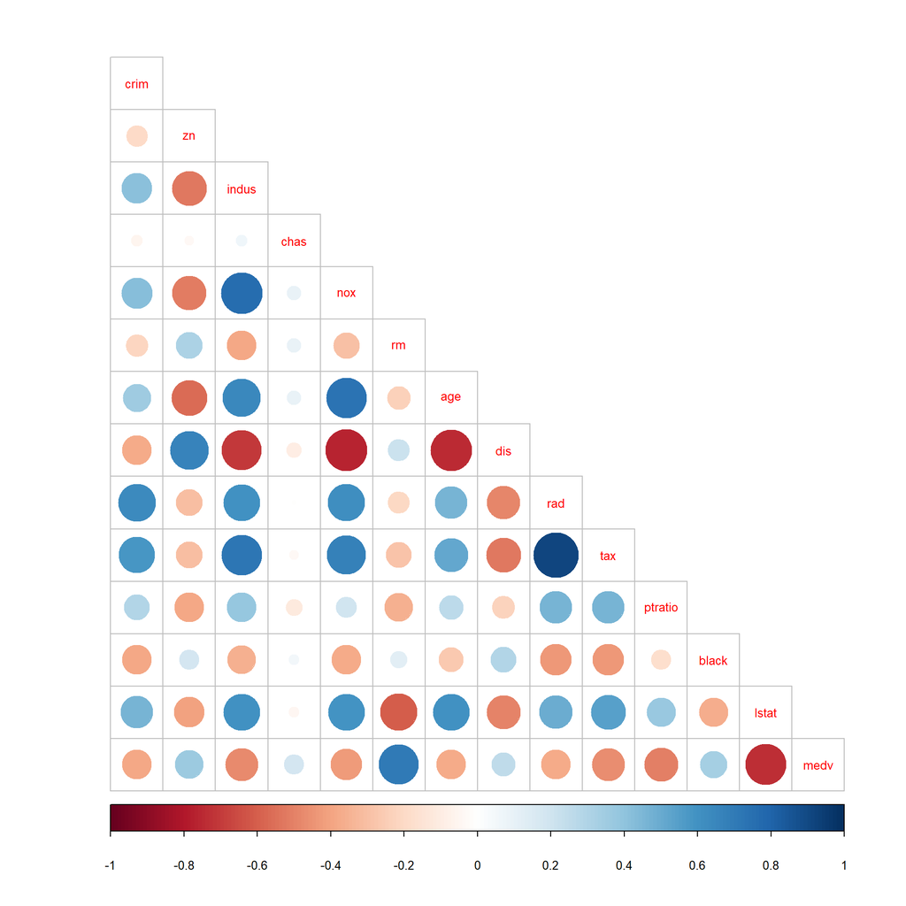

To investigate what factors influence crime rate **crim**, let’s take look at a slightly modified look of the same visualization. **crim** is positively increased as **tax** increased, as well as the accessibility to radial highways **rad**. The proportion of lower class population **lstat** is also correlated.

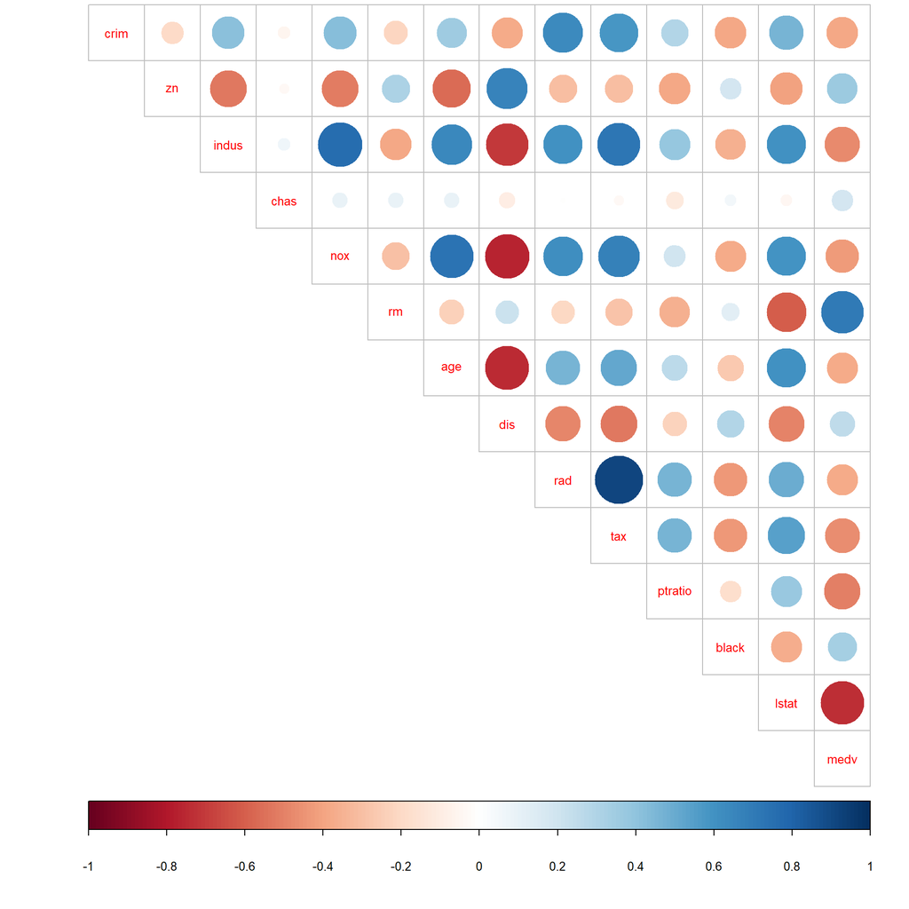

### Standardizing the dataset

The data is scaled (normalized) and summarized as below. Since the value ranges are centered, all mean values are now 0. This way we can use the data for clustering methods, which utilize distance calculation methods, which require each feature to contribute approximately proportionately to the final distance.

```
##       crim                 zn               indus
##  Min.   :-0.419367   Min.   :-0.48724   Min.   :-1.5563
##  1st Qu.:-0.410563   1st Qu.:-0.48724   1st Qu.:-0.8668
##  Median :-0.390280   Median :-0.48724   Median :-0.2109
##  Mean   : 0.000000   Mean   : 0.00000   Mean   : 0.0000
##  3rd Qu.: 0.007389   3rd Qu.: 0.04872   3rd Qu.: 1.0150
##  Max.   : 9.924110   Max.   : 3.80047   Max.   : 2.4202
##       chas              nox                rm               age
##  Min.   :-0.2723   Min.   :-1.4644   Min.   :-3.8764   Min.   :-2.3331
##  1st Qu.:-0.2723   1st Qu.:-0.9121   1st Qu.:-0.5681   1st Qu.:-0.8366
##  Median :-0.2723   Median :-0.1441   Median :-0.1084   Median : 0.3171
##  Mean   : 0.0000   Mean   : 0.0000   Mean   : 0.0000   Mean   : 0.0000
##  3rd Qu.:-0.2723   3rd Qu.: 0.5981   3rd Qu.: 0.4823   3rd Qu.: 0.9059
##  Max.   : 3.6648   Max.   : 2.7296   Max.   : 3.5515   Max.   : 1.1164
##       dis               rad               tax             ptratio
##  Min.   :-1.2658   Min.   :-0.9819   Min.   :-1.3127   Min.   :-2.7047
##  1st Qu.:-0.8049   1st Qu.:-0.6373   1st Qu.:-0.7668   1st Qu.:-0.4876
##  Median :-0.2790   Median :-0.5225   Median :-0.4642   Median : 0.2746
##  Mean   : 0.0000   Mean   : 0.0000   Mean   : 0.0000   Mean   : 0.0000
##  3rd Qu.: 0.6617   3rd Qu.: 1.6596   3rd Qu.: 1.5294   3rd Qu.: 0.8058
##  Max.   : 3.9566   Max.   : 1.6596   Max.   : 1.7964   Max.   : 1.6372
##      black             lstat              medv
##  Min.   :-3.9033   Min.   :-1.5296   Min.   :-1.9063
##  1st Qu.: 0.2049   1st Qu.:-0.7986   1st Qu.:-0.5989
##  Median : 0.3808   Median :-0.1811   Median :-0.1449
##  Mean   : 0.0000   Mean   : 0.0000   Mean   : 0.0000
##  3rd Qu.: 0.4332   3rd Qu.: 0.6024   3rd Qu.: 0.2683
##  Max.   : 0.4406   Max.   : 3.5453   Max.   : 2.9865
```

Crime rate **crim** is replaced with categorical value **crime** (*low*, *med_low*, *med_high*, *high*) using the following code.

```r
# create a quantile vector of crim and print it
bins <- quantile(boston_scaled$crim)

# create a categorical variable 'crime'
crime <- cut(boston_scaled$crim, breaks = bins, include.lowest = TRUE, labels = c("low", "med_low", "med_high", "high"))

# remove original crim from the dataset
boston_scaled <- dplyr::select(boston_scaled, -crim)

# add the new categorical value to scaled data
boston_scaled <- data.frame(boston_scaled, crime)
```

The dataset is divided into two. 80% of the dataset will be used for training, while the remaining 20% will be used for testing.

```r
# number of rows in the Boston dataset
n <- nrow(Boston)

# choose randomly 80% of the rows
ind <- sample(n,  size = n * 0.8)

# create train set
train <- boston_scaled[ind,]

# create test set
test <- boston_scaled[-ind,]
```

### Linear discriminant analysis

Linear discriminant analysis is performed on the training set with crime rate **crime** as the target variable and all the other variables in the dataset as predictor variables. A LDA biplot is visualized as below.

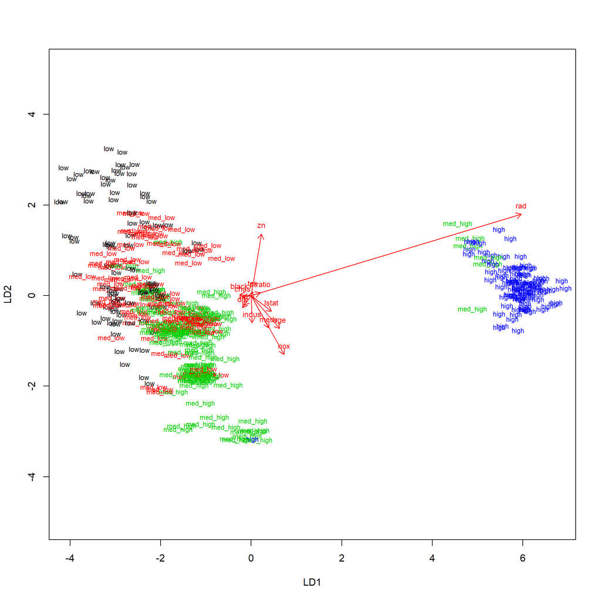

By performing a prediction using the trained linear discriminant model on the test dataset, we obtained a tabulated table on the crime rate **crime**. The diagonal line represents the correct predictions, which mostly account for the majorities. The incorrect number of predictions are kept relatively low.

```
##           predicted
## correct    low med_low med_high high
##   low       23       5        3    0
##   med_low    6      13       11    0
##   med_high   1       4       11    0
##   high       0       0        0   25
```

### K-Means clustering

The Boston dataset is reloaded (and scaled). From here a typical Euclidean and Manhattan distance is calculated to give an idea about the similarity or dissimilarity of observations.

```r
# euclidean distance matrix
dist_eu <- dist(boston_scaled)

# look at the summary of the distances
summary(dist_eu)
```

```
##    Min. 1st Qu.  Median    Mean 3rd Qu.    Max.
##  0.1343  3.4625  4.8241  4.9111  6.1863 14.3970
```

```r
# manhattan distance matrix
dist_man <- dist(boston_scaled, method = "manhattan")

# look at the summary of the distances
summary(dist_man)
```

```
##    Min. 1st Qu.  Median    Mean 3rd Qu.    Max.
##  0.2662  8.4832 12.6090 13.5488 17.7568 48.8618
```

K-Means already runs a built-in distance calculation for its algorithm. So here we run the K-Means algorithm on the Boston dataset with a random number of clusters being 3. However, there isn’t a clear distinction between different class of crime rates with this config.

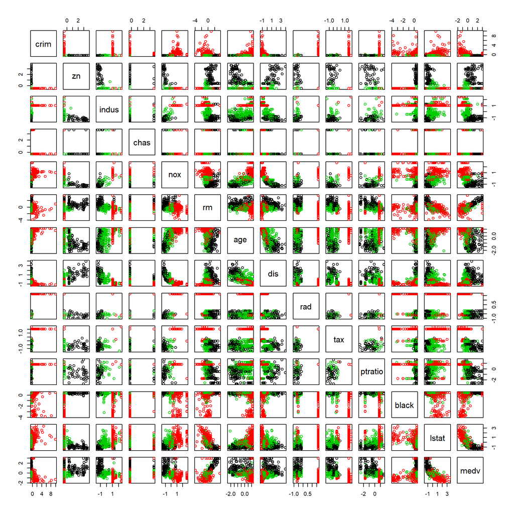

```r
# k-means clustering
km <-kmeans(boston_scaled, centers = 3)

# plot the Boston dataset with clusters
pairs(boston_scaled, col = km$cluster)
```

To find the optimal number of classes (clusters), we visualize the change of total of within cluster sum of squares (WCSS) as k changes. The point of occurence where WCSS changes sharply is where the optimal k lies. In this case, it’s roughly 2.

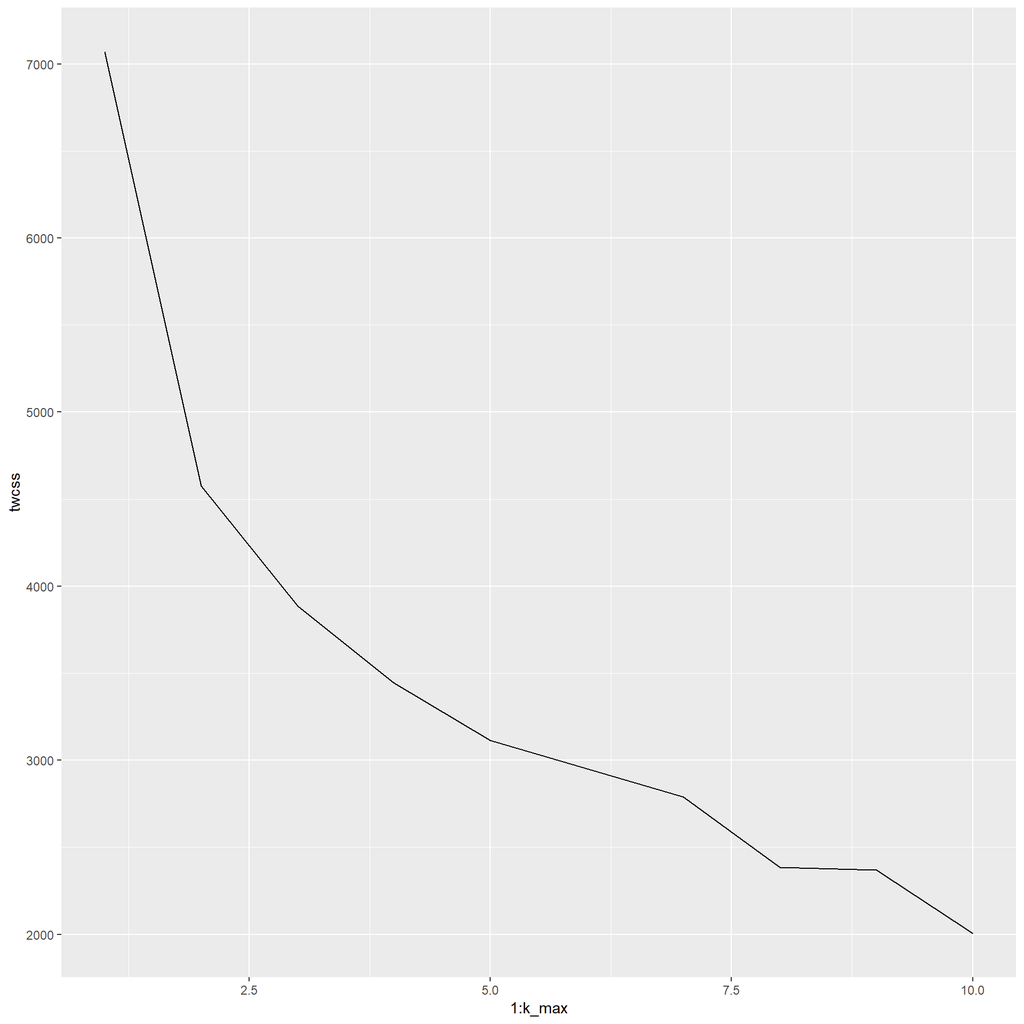

```r
set.seed(123)

# determine the number of clusters
k_max <- 10

# calculate the total within sum of squares
twcss <- sapply(1:k_max, function(k){kmeans(boston_scaled, k)$tot.withinss})

# visualize the results
qplot(x = 1:k_max, y = twcss, geom = 'line')
```

We rerun the K-Means classification algorithm with the number of clusters found above (2). While not perfect, however, the crime rate **crim** classes are now better separated when evaluated against other variables.

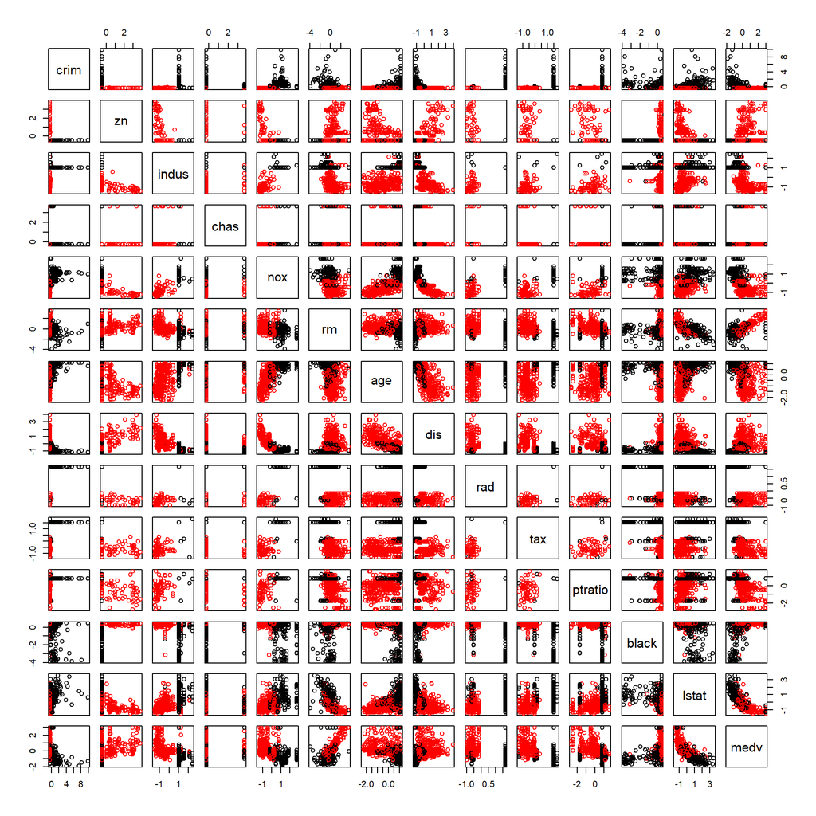

```r
# k-means clustering
km <-kmeans(boston_scaled, centers = 2)

# plot the Boston dataset with clusters
pairs(boston_scaled, col = km$cluster)
```

# 4. Dimensionality reduction techniques

A fairly large selection of statistical methods can be listed under the title *“dimensionality reduction techniques”*. Most often (nearly always, that is!) the real-world phenomena are **multidimensional**: they may consist of not just two or three but 5 or 10 or 20 or 50 (or more) dimensions. Of course, we are living only in a three-dimensional (3D) world, so those multiple dimensions may really challenge our imagination. It would be easier **to reduce the number of dimensions** in one way or another.

In this chapter, we learn the basics of two data science based ways of reducing the dimensions. The key method is **principal component analysis** (PCA), which reduces any number of measured (continuous) and correlated variables into a few uncorrelated components that collect together as much variance as possible from the original variables. The most important components can be then used for various purposes, e.g., drawing scatterplots and other fancy graphs that would be quite impossible to achieve with the original variables and too many dimensions.

**Multiple correspondence analysis** (MCA) and other variations of CA bring us similar possibilities in the **world of discrete variables**, even nominal scale (classified) variables, by finding a suitable transformation into continuous scales and then reducing the dimensions quite analogously with the PCA. The typical graphs show the original classes of the discrete variables on the same “map”, making it possible to reveal **connections** (correspondences) between different things that would be quite impossible to see from the corresponding cross tables (too many numbers!).

Briefly stated, these methods help to visualize and understand multidimensional phenomena by reducing their dimensionality that may first feel impossible to handle at all.

### Data Overview

The data was originally taken from http://hdr.undp.org/en/content/human-development-index-hdi and contains information regarding human development indices on various areas in different countries and regions around the world.

The data being analyzed is a combination of several indicators from most countries in the world, with 155 records and 8 variables. Two major group of indicators are:

##### Health and knowledge

- “GNI” = Gross National Income per capita
- “Life.Exp” = Life expectancy at birth
- “Edu.Exp” = Expected years of schooling
- “Mat.Mor” = Maternal mortality ratio
- “Ado.Birth” = Adolescent birth rate

##### Empowerment

- “Parli.F” = Percetange of female representatives in parliament
- “Edu2.FM” = Edu2.F / Edu2.M
- “Labo.FM” = Labo2.F / Labo2.M
- “Edu2.F” = Proportion of females with at least secondary education
- “Edu2.M” = Proportion of males with at least secondary education
- “Labo.F” = Proportion of females in the labour force
- “Labo.M” " Proportion of males in the labour force

```
## 'data.frame':    155 obs. of  8 variables:
##  $ Edu2.FM  : num  1.007 0.997 0.983 0.989 0.969 ...
##  $ Labo.FM  : num  0.891 0.819 0.825 0.884 0.829 ...
##  $ Edu.Exp  : num  17.5 20.2 15.8 18.7 17.9 16.5 18.6 16.5 15.9 19.2 ...
##  $ Life.Exp : num  81.6 82.4 83 80.2 81.6 80.9 80.9 79.1 82 81.8 ...
##  $ GNI      : int  64992 42261 56431 44025 45435 43919 39568 52947 42155 32689 ...
##  $ Mat.Mor  : int  4 6 6 5 6 7 9 28 11 8 ...
##  $ Ado.Birth: num  7.8 12.1 1.9 5.1 6.2 3.8 8.2 31 14.5 25.3 ...
##  $ Parli.F  : num  39.6 30.5 28.5 38 36.9 36.9 19.9 19.4 28.2 31.4 ...
```

```
##     Edu2.FM          Labo.FM          Edu.Exp         Life.Exp
##  Min.   :0.1717   Min.   :0.1857   Min.   : 5.40   Min.   :49.00
##  1st Qu.:0.7264   1st Qu.:0.5984   1st Qu.:11.25   1st Qu.:66.30
##  Median :0.9375   Median :0.7535   Median :13.50   Median :74.20
##  Mean   :0.8529   Mean   :0.7074   Mean   :13.18   Mean   :71.65
##  3rd Qu.:0.9968   3rd Qu.:0.8535   3rd Qu.:15.20   3rd Qu.:77.25
##  Max.   :1.4967   Max.   :1.0380   Max.   :20.20   Max.   :83.50
##       GNI            Mat.Mor         Ado.Birth         Parli.F
##  Min.   :   581   Min.   :   1.0   Min.   :  0.60   Min.   : 0.00
##  1st Qu.:  4198   1st Qu.:  11.5   1st Qu.: 12.65   1st Qu.:12.40
##  Median : 12040   Median :  49.0   Median : 33.60   Median :19.30
##  Mean   : 17628   Mean   : 149.1   Mean   : 47.16   Mean   :20.91
##  3rd Qu.: 24512   3rd Qu.: 190.0   3rd Qu.: 71.95   3rd Qu.:27.95
##  Max.   :123124   Max.   :1100.0   Max.   :204.80   Max.   :57.50
```

The following plot describe the relationship between variables in the dataset. When it comes to basic education, most countries seem to have a balance ratio between male and female. However, when it comes to labour work force, there is a shift toward a male workforce rather than female. There is still a gap in education periods and life expectancies among contries as there is a big variation in data. The difference between GNI are narrowing down, however, there is still some countries doing way better than others. Maternal mortality is generally low but there are still many cases where the number is quite high. Adolescent birth rate is still quite high overall. Women are taking a bigger role in political landscape, however the majority remain male dominated.

There is a strong correlation across the board between education **Edu.Exp** and life expectancy **Life.Exp**, **GNI**, maternal mortality **Mat.Mor** and adolescent birth rate **Ado.Birth**. Life expectancy **Life.Exp** is naturally linked to **Mat.Mor** and **Ado.Birth** (negative correlation).

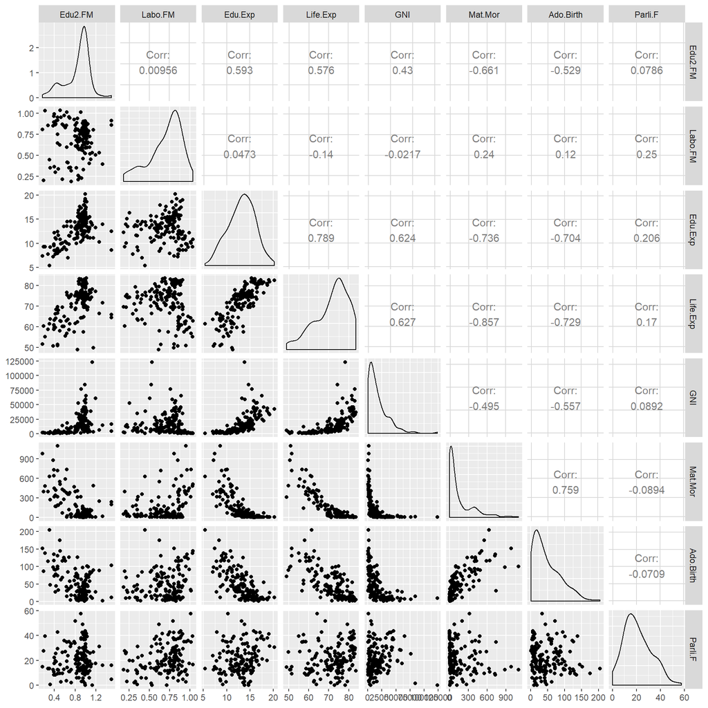

### Principal component analysis

A principal component analysis (PCA) is first performed on the non-standardized data. The following biplot showcases the observations by the first two principal components (PC1, PC2). The arrow and its length represent the correlation between the feature and the corresponding principal component.

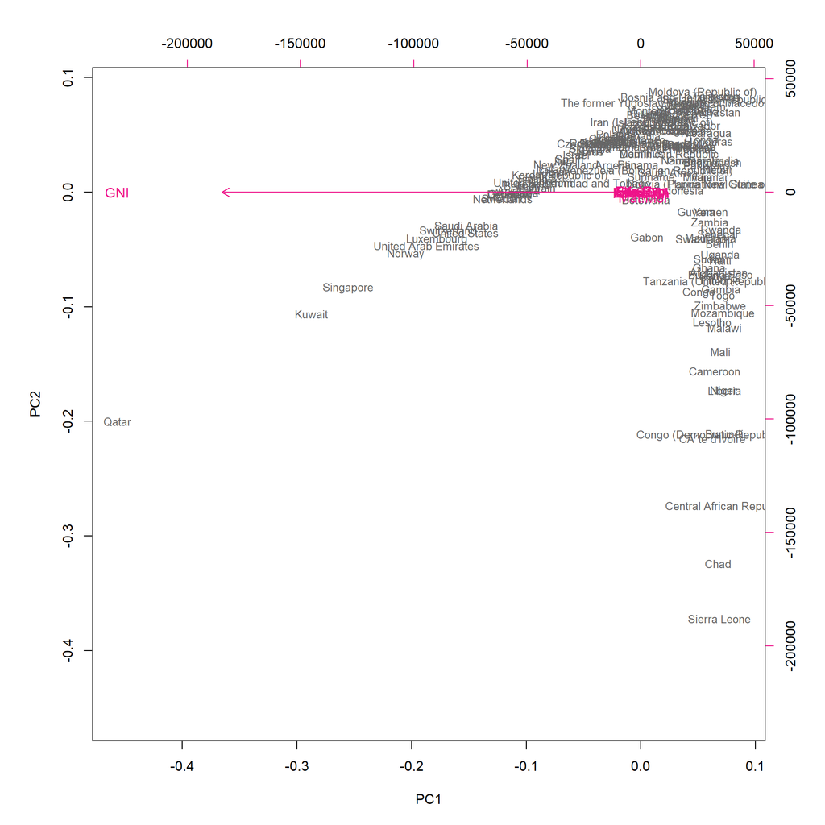

GNI is the only feature to be easily recognized in the plot as having a correlation to PC1. However, this is due to its large value range compared to other variables within the dataset. This makes it quite difficult to interpret the plot and determine which variables are actually having more effect on principal components.

The dataset is then standardized and PCA is performed again. The following is a summary of the normalized dataset, which show all scaled variables and their normalized range, thus more usable for the PCA.

```
##     Edu2.FM           Labo.FM           Edu.Exp           Life.Exp
##  Min.   :-2.8189   Min.   :-2.6247   Min.   :-2.7378   Min.   :-2.7188
##  1st Qu.:-0.5233   1st Qu.:-0.5484   1st Qu.:-0.6782   1st Qu.:-0.6425
##  Median : 0.3503   Median : 0.2316   Median : 0.1140   Median : 0.3056
##  Mean   : 0.0000   Mean   : 0.0000   Mean   : 0.0000   Mean   : 0.0000
##  3rd Qu.: 0.5958   3rd Qu.: 0.7350   3rd Qu.: 0.7126   3rd Qu.: 0.6717
##  Max.   : 2.6646   Max.   : 1.6632   Max.   : 2.4730   Max.   : 1.4218
##       GNI             Mat.Mor          Ado.Birth          Parli.F
##  Min.   :-0.9193   Min.   :-0.6992   Min.   :-1.1325   Min.   :-1.8203
##  1st Qu.:-0.7243   1st Qu.:-0.6496   1st Qu.:-0.8394   1st Qu.:-0.7409
##  Median :-0.3013   Median :-0.4726   Median :-0.3298   Median :-0.1403
##  Mean   : 0.0000   Mean   : 0.0000   Mean   : 0.0000   Mean   : 0.0000
##  3rd Qu.: 0.3712   3rd Qu.: 0.1932   3rd Qu.: 0.6030   3rd Qu.: 0.6127
##  Max.   : 5.6890   Max.   : 4.4899   Max.   : 3.8344   Max.   : 3.1850
```

The biplot is drawn again but this time using the scaled dataset. As shown in the plot, features can be seen together as a groups, which have similar angles to their corresponding principal component. Education **Edu.Exp**, **Edu2.FM** is negatively correlated to adolescent birth **Ado.Birth**, while life expectancy **Life.Exp** is negatively correlated to maternal mortality **Mat.Mor**. Gross national income **GNI** directly goes together with education and life expectancy, while against mortality and teenage birth, as expected. Female anticipation in parliment **Parli.F** can be somewhat related to ratio of female and male in the workforce **Labo.FM**.

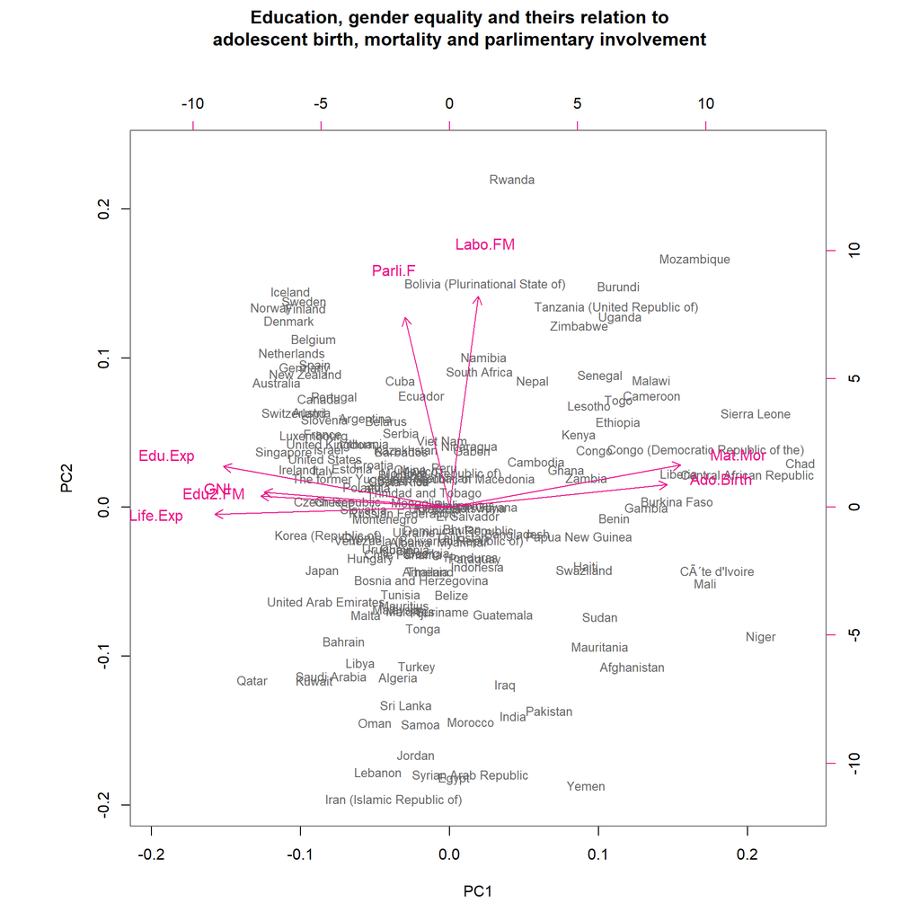

Since **Parli.F** and **Labo.FM** are more aligned to **PC2**, while **Edu.Exp**, **Edu2.FM**, **Life.Exp**,**GNI**, **Mat.Mor** and **Ado.Birth** are more in line with **PC1**, it can be said that the principal components have their implicit meanings.

For **PC1**, it’s understandable to see education, income and life expectancy going hand in hand with each other, as they complement each other in real life. Poor education often lead to lack to youth knowledge and therefore high adolescent birth rate, as well as maternal mortality. This mortality also directly affects life expectancy. Income, however, is more implicit, thus indirectly affects other factors, but still theirs relation are easily understandable. This principal component **PC1** therefore reflects **Health and knowledge** and its effects.

In case of **PC2**, it’s more about **Gender empowerment**. As female become more active in the labor workforce, they also end up being more active in political movement, which is a common side effect in countries where gender equality is well respected.

### The tea dataset

The **tea** dataset from **FactoMineR** library contains a very comprehensive research on how tea are consumed, including where, how, in which environment, etc. **age** is the only variable with integer values, while the rest contain categorical values, which are self-explanatory.

```
## 'data.frame':    300 obs. of  36 variables:
##  $ breakfast       : Factor w/ 2 levels "breakfast","Not.breakfast": 1 1 2 2 1 2 1 2 1 1 ...
##  $ tea.time        : Factor w/ 2 levels "Not.tea time",..: 1 1 2 1 1 1 2 2 2 1 ...
##  $ evening         : Factor w/ 2 levels "evening","Not.evening": 2 2 1 2 1 2 2 1 2 1 ...
##  $ lunch           : Factor w/ 2 levels "lunch","Not.lunch": 2 2 2 2 2 2 2 2 2 2 ...
##  $ dinner          : Factor w/ 2 levels "dinner","Not.dinner": 2 2 1 1 2 1 2 2 2 2 ...
##  $ always          : Factor w/ 2 levels "always","Not.always": 2 2 2 2 1 2 2 2 2 2 ...
##  $ home            : Factor w/ 2 levels "home","Not.home": 1 1 1 1 1 1 1 1 1 1 ...
##  $ work            : Factor w/ 2 levels "Not.work","work": 1 1 2 1 1 1 1 1 1 1 ...
##  $ tearoom         : Factor w/ 2 levels "Not.tearoom",..: 1 1 1 1 1 1 1 1 1 2 ...
##  $ friends         : Factor w/ 2 levels "friends","Not.friends": 2 2 1 2 2 2 1 2 2 2 ...
##  $ resto           : Factor w/ 2 levels "Not.resto","resto": 1 1 2 1 1 1 1 1 1 1 ...
##  $ pub             : Factor w/ 2 levels "Not.pub","pub": 1 1 1 1 1 1 1 1 1 1 ...
##  $ Tea             : Factor w/ 3 levels "black","Earl Grey",..: 1 1 2 2 2 2 2 1 2 1 ...
##  $ How             : Factor w/ 4 levels "alone","lemon",..: 1 3 1 1 1 1 1 3 3 1 ...
```

[output cut: 22 more lines]

To visualize the dataset, a simplified dataset is used where “Tea”, “How”, “how”, “sugar”, “where”, “lunch” variables are kept, as these will be the focus of the upcoming analysis.

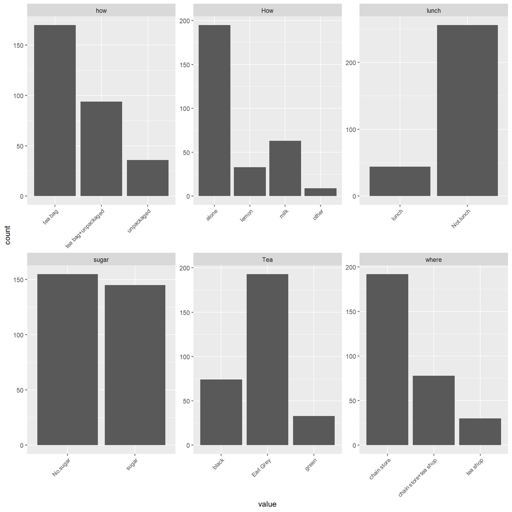

The table below is a summary of the MCA model, performed on the simplified tea dataset. As can be seen from the categorical variables sub-table, the way tea is packaged **how** and **where** it is used are closely related to **Dim.1**, as well as **Dim.2**. Meanwhile, the kind of **Tea** and **How** they are drunk are related to **Dim.3**.

```
##
## Call:
## MCA(X = tea_time, graph = FALSE)
##
##
## Eigenvalues
##                        Dim.1   Dim.2   Dim.3   Dim.4   Dim.5   Dim.6
## Variance               0.279   0.261   0.219   0.189   0.177   0.156
## % of var.             15.238  14.232  11.964  10.333   9.667   8.519
## Cumulative % of var.  15.238  29.471  41.435  51.768  61.434  69.953
##                        Dim.7   Dim.8   Dim.9  Dim.10  Dim.11
## Variance               0.144   0.141   0.117   0.087   0.062
## % of var.              7.841   7.705   6.392   4.724   3.385
## Cumulative % of var.  77.794  85.500  91.891  96.615 100.000
##
## Individuals (the 10 first)
##                       Dim.1    ctr   cos2    Dim.2    ctr   cos2    Dim.3
## 1                  | -0.298  0.106  0.086 | -0.328  0.137  0.105 | -0.327
## 2                  | -0.237  0.067  0.036 | -0.136  0.024  0.012 | -0.695
## 3                  | -0.369  0.162  0.231 | -0.300  0.115  0.153 | -0.202
## 4                  | -0.530  0.335  0.460 | -0.318  0.129  0.166 |  0.211
## 5                  | -0.369  0.162  0.231 | -0.300  0.115  0.153 | -0.202
## 6                  | -0.369  0.162  0.231 | -0.300  0.115  0.153 | -0.202
## 7                  | -0.369  0.162  0.231 | -0.300  0.115  0.153 | -0.202
## 8                  | -0.237  0.067  0.036 | -0.136  0.024  0.012 | -0.695
## 9                  |  0.143  0.024  0.012 |  0.871  0.969  0.435 | -0.067
## 10                 |  0.476  0.271  0.140 |  0.687  0.604  0.291 | -0.650
##                       ctr   cos2
## 1                   0.163  0.104 |
## 2                   0.735  0.314 |
## 3                   0.062  0.069 |
## 4                   0.068  0.073 |
## 5                   0.062  0.069 |
## 6                   0.062  0.069 |
## 7                   0.062  0.069 |
## 8                   0.735  0.314 |
## 9                   0.007  0.003 |
## 10                  0.643  0.261 |
##
## Categories (the 10 first)
```

[output cut: 16 more lines]

```
## lemon                0.035   3.226 |   1.329  14.771   0.218   8.081 |
## milk                 0.020   2.422 |   0.013   0.003   0.000   0.116 |
## other                0.102   5.534 |  -2.524  14.526   0.197  -7.676 |
## tea bag              0.161  -6.941 |  -0.065   0.183   0.006  -1.287 |
## tea bag+unpackaged   0.478  11.956 |   0.019   0.009   0.000   0.226 |
## unpackaged           0.141  -6.482 |   0.257   0.602   0.009   1.640 |
##
## Categorical variables (eta2)
##                      Dim.1 Dim.2 Dim.3
## Tea                | 0.126 0.108 0.410 |
## How                | 0.076 0.190 0.394 |
## how                | 0.708 0.522 0.010 |
## sugar              | 0.065 0.001 0.336 |
## where              | 0.702 0.681 0.055 |
## lunch              | 0.000 0.064 0.111 |
```

The factor map below show the correlation between variables in **Dim.1** and **Dim.2**. It can be clearly seen that tea bag consumption are closely related to chain store, where the tea is bought, while unpackaged tea are usually served at tea shop. Earl Grey tea are generally served with milk, while black tea can be served with either milk, lemon or alone.

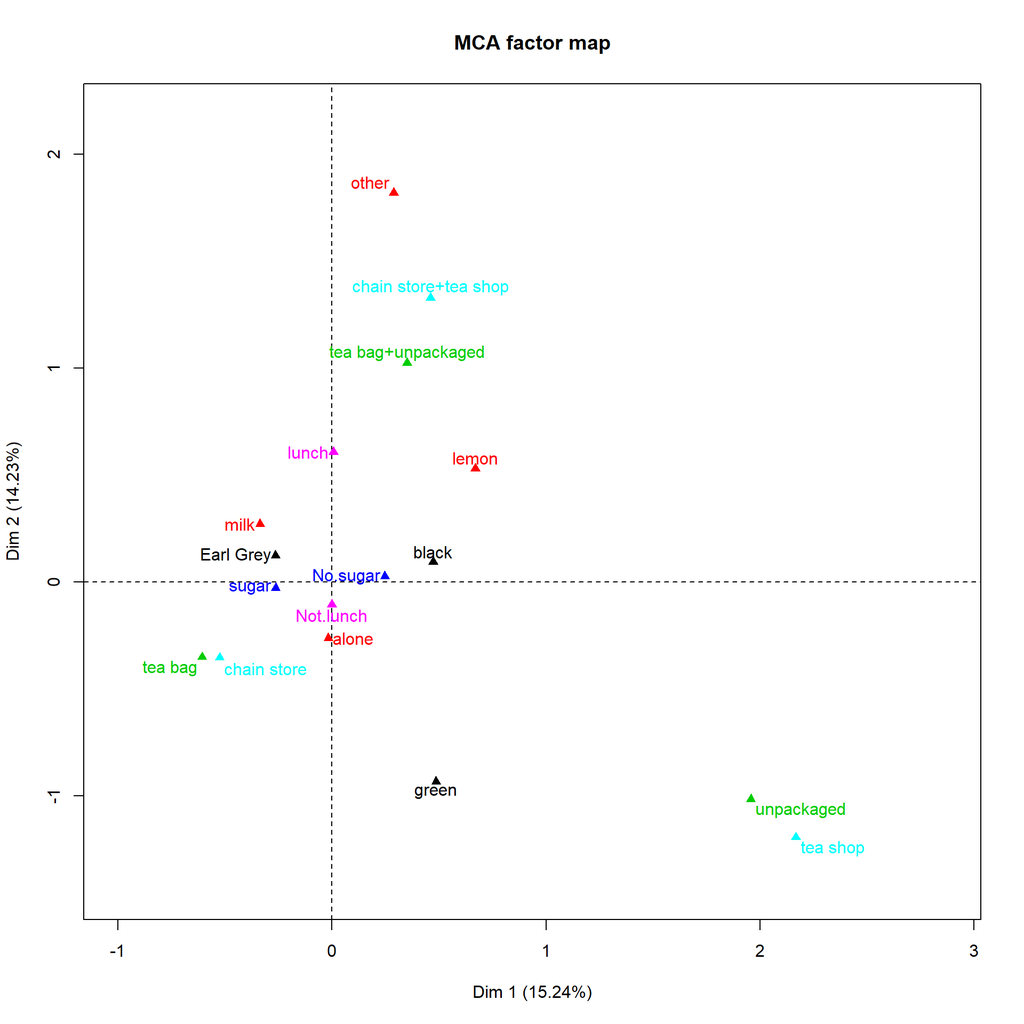

# 5. Analysis of longitudinal data

The last chapter (or topic) of the course takes us back to the task of building **statistical models**, after having worked the last two weeks with multivariate, mostly explorative, even heuristic techniques that are common in data science, including machine learning.

The new challenge here is that the data may (and will) include **two types of dependencies simultaneously**: In addition to the more or less correlated variables that we have faced with all models and methods so far, the **observations of the data will also be intercorrelated**. Usually (in the above mentioned models and methods), we can (often pretty safely) assume that the observations are independent of each other. However, in **longitudinal data** this assumption seldom holds, because we have multiple observations or measurements of the same individuals. The concept of **repeated measures** highlights this phenomenon that is actually quite typical in many applications. Both types of dependencies must be taken into account; otherwise the models will be biased.

To analyze this kind of data sets, we will focus on a single class of methods, called **linear mixed effects models** that can cope quite nicely with the setting described above.

Before we consider two examples of mixed models, namely the random intercept model and the random intercept and slope model, we will learn how to wrangle **longitudinal data in wide form and long form**, take a look at some **graphical displays of longitudinal data**, and try a simple summary measure approach that may sometimes provide a useful first step in these challenges. In passing, we “violently” apply the usual “fixed” models (although we know that they are not the right choice here) in order to compare the results and see the consequences of making invalid assumptions.

### Analysis of RATS data

Below is the description of the long form, condensed RATS data. **Time** describes the week the subject is on, corresponding to its **Weight**. This data study the growth of three separate **Group** of rats on different diets, 16 rats were studied in this experiment.

```
## 'data.frame':    176 obs. of  5 variables:
##  $ ID    : Factor w/ 16 levels "1","2","3","4",..: 1 2 3 4 5 6 7 8 9 10 ...
##  $ Group : Factor w/ 3 levels "1","2","3": 1 1 1 1 1 1 1 1 2 2 ...
##  $ WD    : Factor w/ 11 levels "WD1","WD15","WD22",..: 1 1 1 1 1 1 1 1 1 1 ...
##  $ Weight: int  240 225 245 260 255 260 275 245 410 405 ...
##  $ Time  : int  1 1 1 1 1 1 1 1 1 1 ...
```

All rats amongst all groups displayed certain amount of gain in terms of **Weight** over the 9-week period of the study. However, the gain within group 1 is rather minimal and not obvious compared to group 2 and 3. Group 2 showed the most substantial gain.

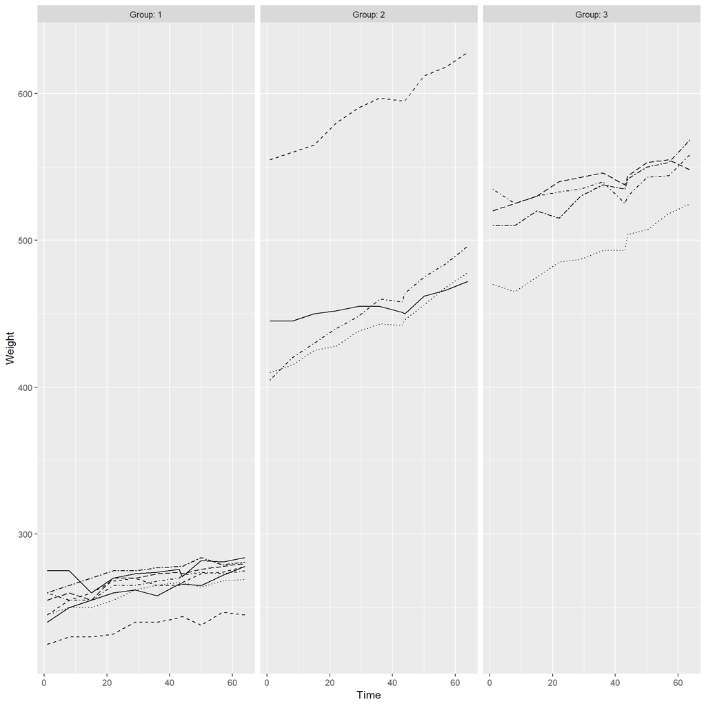

The rats that have higher weight at the beginning tend to have higher weight throughout the study. The phenomenon is referred to as tracking. The tracking phenomenon can be seen more clearly in the plot below, using a standardized dataset of each observation the values obtained by subtracting the relevant occasion mean from the original observation and then dividing by the corresponding visit standard deviation.

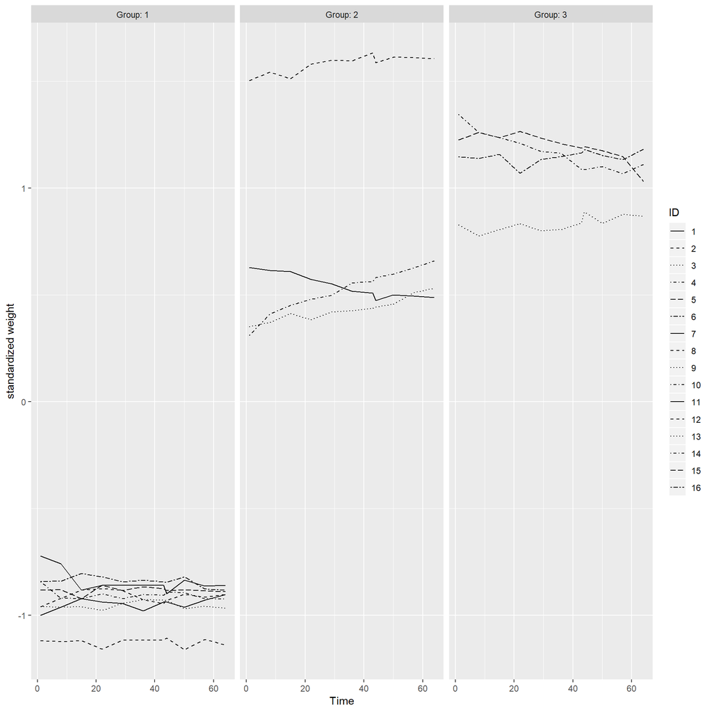

The following graph showcases the mean profile for each individual group, with group 2 clearly has the biggest variance. Coming in second is group 3, while group 1 shows the least variability.

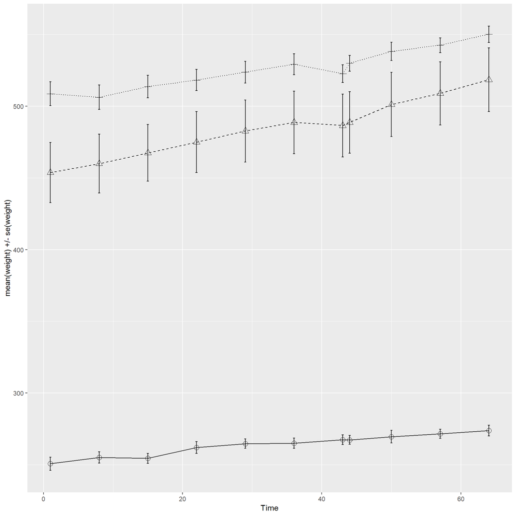

The mean summary is portrayed using the plot down below. However, there is a substantial interference with the boxplot due to outliers.

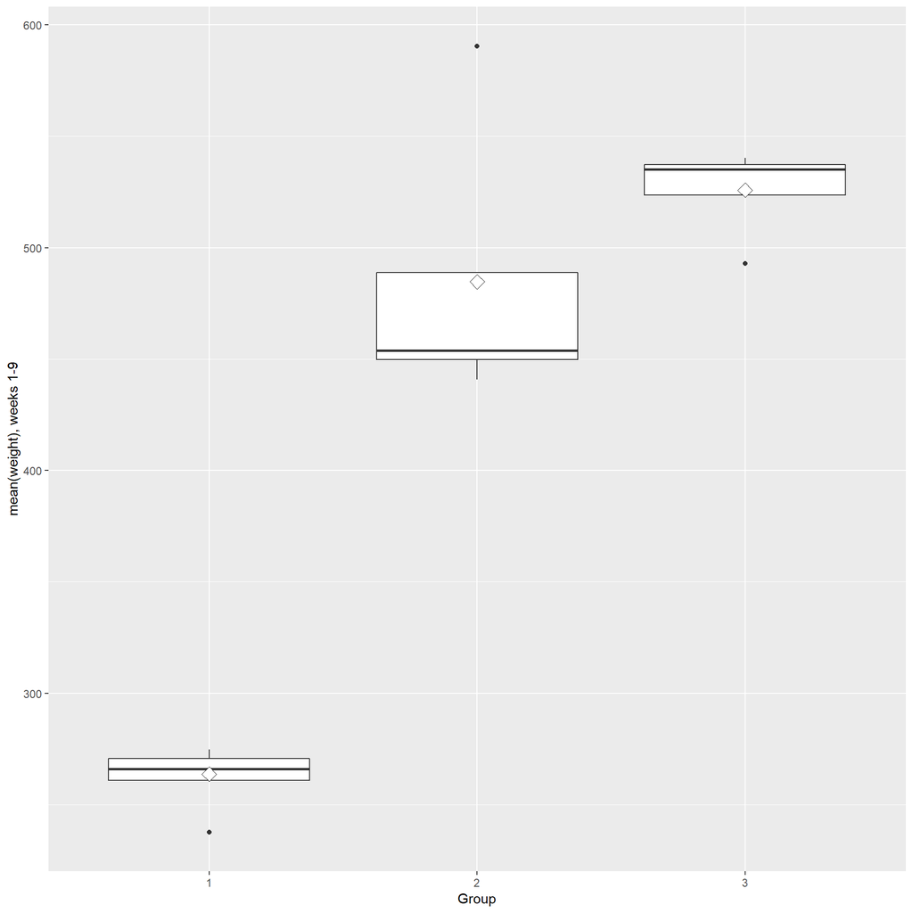

Outliers are removed and the plot is produced again, with much better clarity. Variation are lower and it’s clear that group 1 has the lowest nine-week mean.

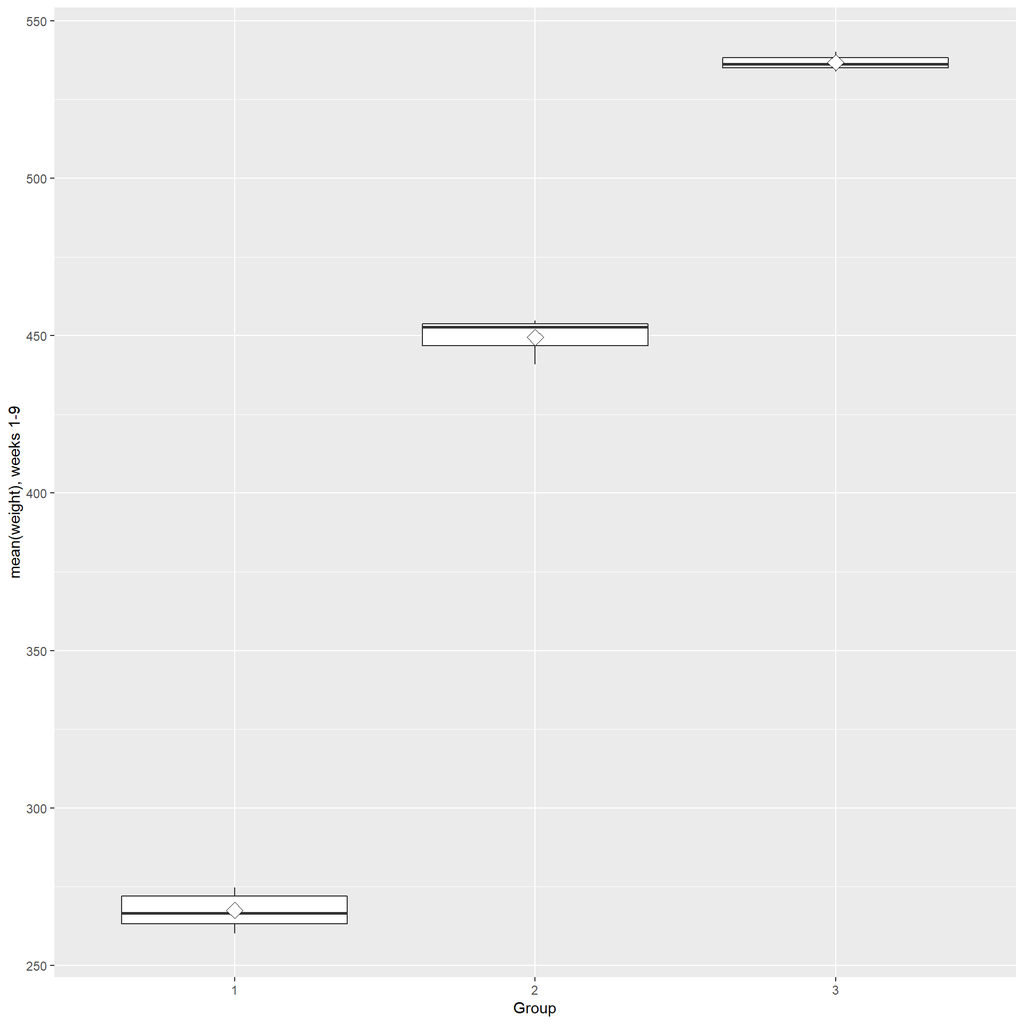

### Analysis of BPRS data

The dataset being analyzed in this section is a long form dataset, which is based on a study on 40 male subjects throughout two separate psychological treatment processes. The week columns are condensed into a single column **weeks** and **week** (as number), this way data can be easily treated as individual records, making it easier to use for the upcoming analysis. **week** indicates the week the subject is on, corresponding to his BPRS score.

```
## 'data.frame':    360 obs. of  5 variables:
##  $ treatment: Factor w/ 2 levels "1","2": 1 1 1 1 1 1 1 1 1 1 ...
##  $ subject  : Factor w/ 20 levels "1","2","3","4",..: 1 2 3 4 5 6 7 8 9 10 ...
##  $ weeks    : Factor w/ 9 levels "week0","week1",..: 1 1 1 1 1 1 1 1 1 1 ...
##  $ bprs     : int  42 58 54 55 72 48 71 30 41 57 ...
##  $ week     : int  0 0 0 0 0 0 0 0 0 0 ...
```

Assuming all measurements are independent of one another, we plot all the observations in the dataset. The BPRS scores show a tendency of decreasing, however not obvious enough.

[figure not shown]

With a linear regression model applied on **bprs** variable with **week** and **treatment** as explanatory variables, the model show a strong correlation with time, rather than the treatment method.

```r
# create a regression model BPRS_reg
BPRS_reg <- lm(bprs ~ week + treatment, data = BPRSL)

# print out a summary of the model
summary(BPRS_reg)
```

```
##
## Call:
## lm(formula = bprs ~ week + treatment, data = BPRSL)
##
## Residuals:
##     Min      1Q  Median      3Q     Max
## -22.454  -8.965  -3.196   7.002  50.244
##
## Coefficients:
##             Estimate Std. Error t value Pr(>|t|)
## (Intercept)  46.4539     1.3670  33.982   <2e-16 ***
## week         -2.2704     0.2524  -8.995   <2e-16 ***
## treatment2    0.5722     1.3034   0.439    0.661
## ---
## Signif. codes:  0 '***' 0.001 '**' 0.01 '*' 0.05 '.' 0.1 ' ' 1
##
## Residual standard error: 12.37 on 357 degrees of freedom
## Multiple R-squared:  0.1851, Adjusted R-squared:  0.1806
## F-statistic: 40.55 on 2 and 357 DF,  p-value: < 2.2e-16
```

The previous model assumes independence of the repeated measures of BPRS, and this assumption is highly unlikely. So we will move on to consider more appropriate models.

We will first fit the random intercept model for the same two explanatory variables: **week** and **treatment**. Fitting a random intercept model allows the linear regression fit for each man to differ in **intercept** from other men. This explains the high variance (and std.dev.) for **subject** variable in the model.

```r
# access library lme4
library(lme4)

# Create a random intercept model
BPRS_ref <- lmer(bprs ~ week + treatment + (1 | subject), data = BPRSL, REML = FALSE)

# Print the summary of the model
summary(BPRS_ref)
```

```
## Linear mixed model fit by maximum likelihood  ['lmerMod']
## Formula: bprs ~ week + treatment + (1 | subject)
##    Data: BPRSL
##
##      AIC      BIC   logLik deviance df.resid
##   2748.7   2768.1  -1369.4   2738.7      355
##
## Scaled residuals:
##     Min      1Q  Median      3Q     Max
## -3.0481 -0.6749 -0.1361  0.4813  3.4855
##
## Random effects:
##  Groups   Name        Variance Std.Dev.
##  subject  (Intercept)  47.41    6.885
##  Residual             104.21   10.208
## Number of obs: 360, groups:  subject, 20
##
## Fixed effects:
##             Estimate Std. Error t value
## (Intercept)  46.4539     1.9090  24.334
## week         -2.2704     0.2084 -10.896
## treatment2    0.5722     1.0761   0.532
##
## Correlation of Fixed Effects:
##            (Intr) week
## week       -0.437
## treatment2 -0.282  0.000
```

Now we can fit the random intercept and random slope model to the data. Fitting a random intercept and random slope model allows the linear regression fits for each individual to differ in intercept but also in slope. This way it is possible to account for the individual differences in the BPRS score profiles, but also the effect of time.

```r
# create a random intercept and random slope model
BPRS_ref1 <- lmer(bprs ~ week + treatment + (week | subject), data = BPRSL, REML = FALSE)

# print a summary of the model
summary(BPRS_ref1)
```

```
## Linear mixed model fit by maximum likelihood  ['lmerMod']
## Formula: bprs ~ week + treatment + (week | subject)
##    Data: BPRSL
##
##      AIC      BIC   logLik deviance df.resid
##   2745.4   2772.6  -1365.7   2731.4      353
##
## Scaled residuals:
##     Min      1Q  Median      3Q     Max
## -2.8919 -0.6194 -0.0691  0.5531  3.7976
##
## Random effects:
##  Groups   Name        Variance Std.Dev. Corr
##  subject  (Intercept) 64.8202  8.0511
##           week         0.9608  0.9802   -0.51
##  Residual             97.4307  9.8707
## Number of obs: 360, groups:  subject, 20
##
## Fixed effects:
##             Estimate Std. Error t value
## (Intercept)  46.4539     2.1052  22.066
## week         -2.2704     0.2977  -7.626
## treatment2    0.5722     1.0405   0.550
##
## Correlation of Fixed Effects:
##            (Intr) week
## week       -0.582
## treatment2 -0.247  0.000
```

```r
# perform an ANOVA test on the two models
anova(BPRS_ref1, BPRS_ref)
```

```
## Data: BPRSL
## Models:
## BPRS_ref: bprs ~ week + treatment + (1 | subject)
## BPRS_ref1: bprs ~ week + treatment + (week | subject)
##           Df    AIC    BIC  logLik deviance  Chisq Chi Df Pr(>Chisq)
## BPRS_ref   5 2748.7 2768.1 -1369.4   2738.7
## BPRS_ref1  7 2745.4 2772.6 -1365.7   2731.4 7.2721      2    0.02636 *
## ---
## Signif. codes:  0 '***' 0.001 '**' 0.01 '*' 0.05 '.' 0.1 ' ' 1
```

```r
# create a random intercept and random slope model with the interaction
BPRS_ref2 <- lmer(bprs ~ week + treatment + (week | treatment), data = BPRSL, REML = FALSE)
```

```
## singular fit
```

```r
# print a summary of the model
summary(BPRS_ref2)
```

```
## Linear mixed model fit by maximum likelihood  ['lmerMod']
## Formula: bprs ~ week + treatment + (week | treatment)
##    Data: BPRSL
##
##      AIC      BIC   logLik deviance df.resid
##   2843.3   2870.5  -1414.7   2829.3      353
##
## Scaled residuals:
##     Min      1Q  Median      3Q     Max
## -1.8252 -0.7277 -0.2586  0.5697  4.0818
##
## Random effects:
##  Groups    Name        Variance  Std.Dev. Corr
##  treatment (Intercept) 2.820e-02  0.16794
##            week        1.763e-03  0.04199 -1.00
##  Residual              1.516e+02 12.31302
## Number of obs: 360, groups:  treatment, 2
##
## Fixed effects:
##             Estimate Std. Error t value
## (Intercept)  46.4539     1.3664  33.997
## week         -2.2704     0.2531  -8.971
## treatment2    0.5722     1.2979   0.441
##
## Correlation of Fixed Effects:
##            (Intr) week
## week       -0.741
## treatment2 -0.475  0.000
## convergence code: 0
## singular fit
```

```r
# perform an ANOVA test on the two models
anova(BPRS_ref2, BPRS_ref1)
```

```
## Data: BPRSL
## Models:
## BPRS_ref2: bprs ~ week + treatment + (week | treatment)
## BPRS_ref1: bprs ~ week + treatment + (week | subject)
##           Df    AIC    BIC  logLik deviance  Chisq Chi Df Pr(>Chisq)
## BPRS_ref2  7 2843.3 2870.5 -1414.7   2829.3
## BPRS_ref1  7 2745.4 2772.6 -1365.7   2731.4 97.896      0  < 2.2e-16 ***
## ---
## Signif. codes:  0 '***' 0.001 '**' 0.01 '*' 0.05 '.' 0.1 ' ' 1
```

```r
# Create a vector of the fitted values
Fitted <- fitted(BPRS_ref2)

# Create a new column fitted to BPRSL
BPRSL$Fitted <- Fitted
```